# Hierarchical Clustering of IGT Scoring Methods

Annika Kuelpmann

2026-10-07

```r
library(tidyverse)
library(here)
library(dynamicTreeCut)
library(dendextend)
library(paletteer)
source(here::here("code", "aps_figure_helpers.R"))
```

## Data

```r
# file has id plus 197 scoring method columns, drop id and the zero variance A_60_cutoff to leave 196
data_whole <- read_csv(here("data", "processed", "multiverse",
                            "data_processed_participant_level.csv")) %>%
  select(-id, -A_60_cutoff)

cat("Scoring methods:", ncol(data_whole), "| participants:", nrow(data_whole), "\n")
```

```
## Scoring methods: 196 | participants: 504
```

## Correlation matrix

```r
cor_whole <- cor(data_whole, use = "pairwise.complete.obs")
cat("Correlation matrix dimensions:", nrow(cor_whole), "×", ncol(cor_whole), "\n")
```

```
## Correlation matrix dimensions: 196 × 196
```

```r
# long form upper triangle without self pairs, reused in both clustering sections
cor_long <- cor_whole %>%
  as_tibble(rownames = "method_x") %>%
  pivot_longer(-method_x, names_to = "method_y", values_to = "r") %>%
  filter(method_x < method_y)
```

```r
# correlation thresholds for dendrogram cut lines, shared by both sections
r_cuts <- c(0.9, 0.7, 0.5, 0.3, 0.1, 0.0)
```

```r
# returns one list element per r threshold holding a one row summary tibble
cuts_summary <- function(hc, cor_long, r_cuts) {
  map(r_cuts, function(r_thresh) {
    clusters   <- cutree(hc, h = 1 - r_thresh)
    n_clusters <- length(unique(clusters))
    labels     <- tibble(method = names(clusters), cluster = clusters)

    cor_cl <- cor_long %>%
      left_join(labels %>% rename(method_x = method, cluster_x = cluster),
                by = "method_x") %>%
      left_join(labels %>% rename(method_y = method, cluster_y = cluster),
                by = "method_y")

    # signed within cluster mean r, singletons have no pairs and are skipped
    within <- cor_cl %>%
      filter(cluster_x == cluster_y) %>%
      group_by(cluster = cluster_x) %>%
      summarise(within_mean_r = mean(r, na.rm = TRUE), .groups = "drop")

    # max between-cluster mean r (NA if only one cluster)
    if (n_clusters > 1) {
      max_between <- cor_cl %>%
        filter(cluster_x != cluster_y) %>%
        mutate(
          pair_lo = pmin(cluster_x, cluster_y),
          pair_hi = pmax(cluster_x, cluster_y)
        ) %>%
        group_by(pair_lo, pair_hi) %>%
        summarise(mean_r = mean(r, na.rm = TRUE), .groups = "drop") %>%
        pull(mean_r) %>%
        max(na.rm = TRUE)
    } else {
      max_between <- NA_real_
    }

    list(
      summary = tibble(
        r_threshold        = r_thresh,
        n_clusters         = n_clusters,
        min_within_mean_r  = round(min(within$within_mean_r, na.rm = TRUE), 3),
        max_between_mean_r = round(max_between, 3)
      )
    )
  })
}
```

```r
# returns a list with a summary tibble and a per cluster tibble
# cluster 0 from cutreeDynamic means unassigned and is excluded from the stats
dyncut_summary <- function(clusters_vec, labels_vec, cor_long) {
  labels <- tibble(method = labels_vec, cluster = clusters_vec)

  n_unassigned <- sum(clusters_vec == 0)
  assigned     <- labels %>% filter(cluster != 0)
  n_clusters   <- length(unique(assigned$cluster))

  cor_cl <- cor_long %>%
    left_join(assigned %>% rename(method_x = method, cluster_x = cluster),
              by = "method_x") %>%
    left_join(assigned %>% rename(method_y = method, cluster_y = cluster),
              by = "method_y") %>%
    filter(!is.na(cluster_x), !is.na(cluster_y))

  # within-cluster mean r (signed; NA for singletons)
  within <- cor_cl %>%
    filter(cluster_x == cluster_y) %>%
    group_by(cluster = cluster_x) %>%
    summarise(within_mean_r = mean(r, na.rm = TRUE), .groups = "drop")

  # centroid: method with highest mean r to all others in its cluster
  centroid_tbl <- bind_rows(
    cor_cl %>%
      filter(cluster_x == cluster_y) %>%
      select(cluster = cluster_x, method = method_x, r),
    cor_cl %>%
      filter(cluster_x == cluster_y) %>%
      select(cluster = cluster_y, method = method_y, r)
  ) %>%
    group_by(cluster, method) %>%
    summarise(mean_r = mean(r, na.rm = TRUE), .groups = "drop") %>%
    group_by(cluster) %>%
    slice_max(mean_r, n = 1, with_ties = FALSE) %>%
    ungroup() %>%
    select(cluster, centroid = method)

  # singletons have no within-cluster pairs, so centroid is just the method name
  singleton_clusters <- setdiff(unique(assigned$cluster), centroid_tbl$cluster)
  if (length(singleton_clusters) > 0) {
    centroid_tbl <- bind_rows(
      centroid_tbl,
      assigned %>% filter(cluster %in% singleton_clusters) %>% rename(centroid = method)
    )
  }

  cluster_tbl <- assigned %>%
    count(cluster, name = "n_methods") %>%
    left_join(within,       by = "cluster") %>%
    left_join(centroid_tbl, by = "cluster") %>%
    mutate(within_mean_r = round(within_mean_r, 3)) %>%
    arrange(cluster)

  # max between-cluster mean r (NA if only one cluster)
  if (n_clusters > 1) {
    max_between <- cor_cl %>%
      filter(cluster_x != cluster_y) %>%
      mutate(
        pair_lo = pmin(cluster_x, cluster_y),
        pair_hi = pmax(cluster_x, cluster_y)
      ) %>%
      group_by(pair_lo, pair_hi) %>%
      summarise(mean_r = mean(r, na.rm = TRUE), .groups = "drop") %>%
      pull(mean_r) %>%
      max(na.rm = TRUE)
  } else {
    max_between <- NA_real_
  }

  list(
    summary = tibble(
      n_clusters         = n_clusters,
      n_unassigned       = n_unassigned,
      min_within_mean_r  = round(min(within$within_mean_r, na.rm = TRUE), 3),
      max_between_mean_r = round(max_between, 3)
    ),
    clusters = cluster_tbl
  )
}
```

## Primary analysis — average linkage, 1 − r

With average linkage the merge height equals the average pairwise distance between the joined groups. Because distance = `1 − r`, height = `1 − r_avg`, so the y-axis can be read directly as a Pearson *r* value (−1 to +1). Negatively correlated methods appear in separate branches.

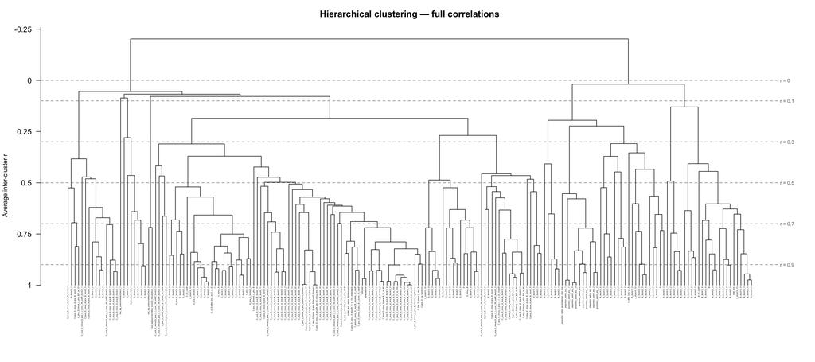

```r
dist_avg <- as.dist(1 - cor_whole)
hc_avg   <- hclust(dist_avg, method = "average")

at_h   <- seq(0, 2, by = 0.25)
at_lbl <- 1 - at_h

par(mar = c(2, 4.5, 3, 4))
plot(hc_avg,
     main = "Hierarchical clustering — full correlations",
     xlab = "",
     sub  = paste0("Distance: 1 − r  |  Linkage: average  |  n = ", ncol(data_whole)),
     ylab = "",
     yaxt = "n",
     cex  = 0.25,
     hang = -1)
axis(2, at = at_h, labels = at_lbl, las = 1)
mtext("Average inter-cluster r", side = 2, line = 3.5, cex = 0.85)
abline(h = 1 - r_cuts, col = "gray40", lty = 2, lwd = 0.8)
text(x = par("usr")[2], y = 1 - r_cuts,
     labels = paste0(" r = ", r_cuts),
     adj = c(0, 0.5), cex = 0.65, col = "gray40", xpd = TRUE)
```

```r
# y axis ticks on the tree height scale where height is 1 minus average r
export_ticks <- seq(0, 1.25, by = 0.25)

# dendrogram with tiny leaf labels and no leaf points, optionally coloured by cluster
make_export_dend <- function(clusters = NULL, palette = NULL, lwd) {
  dend <- as.dendrogram(hc_avg)
  if (!is.null(clusters)) {
    dend <- dend %>%
      color_branches(clusters = clusters, col = palette)
  }
  dend %>%
    set("labels_cex", 0.18) %>%
    set("leaves_pch", NA) %>%
    set("branches_lwd", lwd)
}

# draws the export dendrogram with axis, axis label and optional cut lines
draw_export_dend <- function(clusters = NULL, palette = NULL, cut_lines) {
  par(mar = c(4.6, 4.2, 0.6, if (cut_lines) 3.2 else 0.8), family = font_family,
      mgp = c(3, 0.6, 0), tcl = -0.25, xpd = FALSE)
  plot(make_export_dend(clusters, palette, 0.6),
       yaxt = "n",
       ylim = c(0, max(export_ticks)))
  axis(2, at = export_ticks, labels = label_minus(2)(1 - export_ticks),
       las = 1, cex.axis = 0.8, lwd = 0.6)
  mtext(expression("Average Inter-Cluster " * italic(r)), side = 2, line = 3, cex = 0.85)

  # dashed cut lines at the r thresholds, labelled in the right margin
  if (cut_lines) {
    abline(h = 1 - r_cuts, col = "gray40", lty = 2, lwd = 0.5)
    text(x = par("usr")[2], y = 1 - r_cuts,
         labels = paste0(" r = ", formatC(r_cuts, format = "f", digits = 1)),
         adj = c(0, 0.5), cex = 0.6, col = "gray30", xpd = TRUE)
  }
}

# writes the figure as svg and 600 dpi png at the final size
# the svg keeps text as whole strings
save_export_dend <- function(name, clusters = NULL, palette = NULL, cut_lines,
                             width = 9, height = 4.6) {
  svglite::svglite(paste0(name, ".svg"), width = width, height = height,
                   system_fonts = list(sans = font_family))
  draw_export_dend(clusters, palette, cut_lines)
  invisible(dev.off())
  svg_inline_styles(paste0(name, ".svg"))

  ragg::agg_png(paste0(name, ".png"), width = width, height = height,
                units = "in", res = 600, background = "white")
  draw_export_dend(clusters, palette, cut_lines)
  invisible(dev.off())
}

save_export_dend("KuelpmannFigS1", cut_lines = TRUE)
```

### Cophenetic correlation

```r
coph_r_avg <- cor(dist_avg, cophenetic(hc_avg))
cat("Cophenetic correlation:", round(coph_r_avg, 3), "\n")
```

```
## Cophenetic correlation: 0.826
```

### Cluster structure at each threshold

```r
results_avg <- cuts_summary(hc_avg, cor_long, r_cuts)

for (res in results_avg) {
  s <- res$summary
  cat("\n\n#### Cut at r =", s$r_threshold, "→", s$n_clusters, "clusters\n\n")
  cat("min within-cluster mean r =", s$min_within_mean_r,
      " | max between-cluster mean r =", s$max_between_mean_r, "\n\n")
  cat("\n")
}
```

#### Cut at r = 0.9 → 152 clusters

min within-cluster mean r = 0.902 | max between-cluster mean r = 0.898

#### Cut at r = 0.7 → 85 clusters

min within-cluster mean r = 0.718 | max between-cluster mean r = 0.698

#### Cut at r = 0.5 → 37 clusters

min within-cluster mean r = 0.629 | max between-cluster mean r = 0.497

#### Cut at r = 0.3 → 13 clusters

min within-cluster mean r = 0.403 | max between-cluster mean r = 0.28

#### Cut at r = 0.1 → 7 clusters

min within-cluster mean r = 0.317 | max between-cluster mean r = 0.086

#### Cut at r = 0 → 2 clusters

min within-cluster mean r = 0.187 | max between-cluster mean r = -0.202

## Dynamic Hybrid Cut — 1 − r

The Dynamic Hybrid Cut Algorithm (`cutreeDynamic`, `dynamicTreeCut`) combines dendrogram topology with PAM-based refinement to select cluster boundaries automatically, without requiring a fixed height threshold. `deepSplit` (0–4) controls sensitivity: higher values produce more, smaller clusters. Methods assigned to cluster 0 were not placed in any cluster by the algorithm.

```r
dyn_avg <- cutreeDynamic(
  dendro            = hc_avg,
  distM             = as.matrix(dist_avg),
  method            = "hybrid",
  deepSplit         = 2,
  minClusterSize    = 5,
  pamRespectsDendro = TRUE
)
```

```
##  ..cutHeight not given, setting it to 1.19  ===>  99% of the (truncated) height range in dendro.
##  ..done.
```

### Cluster structure

```r
res_dyn_avg <- dyncut_summary(dyn_avg, colnames(cor_whole), cor_long)
s <- res_dyn_avg$summary

cat("Clusters found:", s$n_clusters, " | Unassigned:", s$n_unassigned, "\n\n")
```

Clusters found: 20 | Unassigned: 0

```r
cat("min within-cluster mean r =", s$min_within_mean_r,
    " | max between-cluster mean r =", s$max_between_mean_r, "\n\n")
```

min within-cluster mean r = 0.418 | max between-cluster mean r = 0.641

```r
print(knitr::kable(res_dyn_avg$clusters))
```

| cluster | n_methods | within_mean_r | centroid |
| --- | --- | --- | --- |
| 1 | 38 | 0.606 | C_plus_D_minus_A_plus_B_51_to_100 |
| 2 | 15 | 0.526 | C_plus_D_minus_A_plus_B_block20_1 |
| 3 | 13 | 0.613 | C_plus_D_minus_A_plus_B_11_to_50 |
| 4 | 13 | 0.765 | C_block25_3 |
| 5 | 11 | 0.688 | proportion_switch_any |
| 6 | 11 | 0.661 | D_block25_3 |
| 7 | 10 | 0.700 | B_block33_3 |
| 8 | 10 | 0.591 | B_block33_2 |
| 9 | 8 | 0.681 | C_plus_D_minus_A_plus_B_block20_3 |
| 10 | 8 | 0.418 | C_block25_1 |
| 11 | 8 | 0.484 | A_block25_2 |
| 12 | 7 | 0.747 | C_plus_D_minus_A_plus_B_last_33_minus_first_33 |
| 13 | 7 | 0.479 | D_block20_5 |
| 14 | 6 | 0.893 | C_block25_4 |
| 15 | 6 | 0.552 | A_block20_4 |
| 16 | 5 | 0.737 | A_block20_5 |
| 17 | 5 | 0.681 | B_block25_1 |
| 18 | 5 | 0.625 | A_block20_1 |
| 19 | 5 | 0.726 | C_block25_2 |
| 20 | 5 | 0.602 | D_block10_4 |

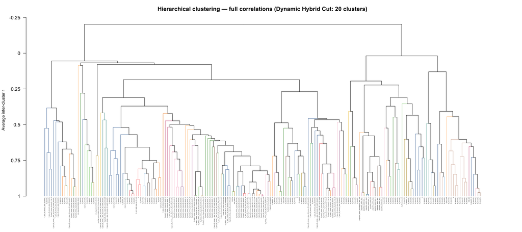

```r
clust_avg <- setNames(dyn_avg, colnames(cor_whole))
unique_cl <- sort(unique(clust_avg))
n_real    <- sum(unique_cl != 0)
pal_avg   <- c(if (0L %in% unique_cl) "gray70",
               rep_len(as.character(paletteer_d("ggthemes::Tableau_20")), n_real))

dend_avg_col <- as.dendrogram(hc_avg) %>%
  color_branches(clusters = clust_avg, col = pal_avg) %>%
  set("labels_cex", 0.25) %>%
  set("leaves_pch", NA)

par(mar = c(5, 4.5, 3, 4))
plot(dend_avg_col,
     main = paste0("Hierarchical clustering — full correlations",
                   " (Dynamic Hybrid Cut: ", res_dyn_avg$summary$n_clusters, " clusters)"),
     xlab = "",
     sub  = "",
     ylab = "",
     yaxt = "n")
axis(2, at = at_h, labels = at_lbl, las = 1)
mtext("Average inter-cluster r", side = 2, line = 3.5, cex = 0.85)
```

```r
# checks the sample and reports the cluster solution shown in figure s2
stopifnot(nrow(data_whole) == 504, ncol(data_whole) == 196)
cat("Participants:", nrow(data_whole), "| methods:", ncol(data_whole),
    "| clusters:", res_dyn_avg$summary$n_clusters,
    "| unassigned:", res_dyn_avg$summary$n_unassigned, "\n")
```

```
## Participants: 504 | methods: 196 | clusters: 20 | unassigned: 0
```

```r
# figure s2 with branches coloured by the dynamic hybrid cut clusters
save_export_dend("KuelpmannFigS2", clusters = clust_avg, palette = pal_avg, cut_lines = FALSE)
```

## Sensitivity check — absolute correlation distance

Distance = `1 − |r|`: two methods are treated as similar whenever they move in lock-step, regardless of sign. Methods that are directional opposites (e.g. proportion of good-deck vs. bad-deck choices) now cluster together. The y-axis shows the average |r| at which groups merged. Comparing with the primary dendrogram above reveals which methods are “mirror images” of one another — same cluster here, different cluster above.

Note: within-cluster mean r in this section uses the original signed r. A cluster formed because two methods share high |r| but opposite sign will show a negative within-cluster mean r.

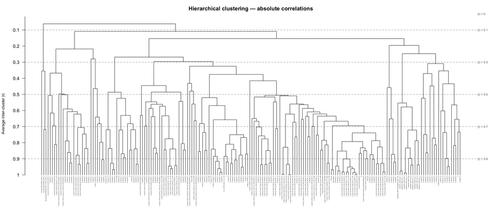

```r
dist_abs <- as.dist(1 - abs(cor_whole))
hc_abs   <- hclust(dist_abs, method = "average")

at_h_abs   <- seq(0, 1, by = 0.1)
at_lbl_abs <- 1 - at_h_abs

par(mar = c(2, 4.5, 3, 4))
plot(hc_abs,
     main = "Hierarchical clustering — absolute correlations",
     xlab = "",
     sub  = paste0("Distance: 1 − |r|  |  Linkage: average  |  n = ", ncol(data_whole)),
     ylab = "",
     yaxt = "n",
     cex  = 0.25,
     hang = -1)
axis(2, at = at_h_abs, labels = at_lbl_abs, las = 1)
mtext("Average inter-cluster |r|", side = 2, line = 3.5, cex = 0.85)
abline(h = 1 - r_cuts, col = "gray40", lty = 2, lwd = 0.8)
text(x = par("usr")[2], y = 1 - r_cuts,
     labels = paste0(" |r| = ", r_cuts),
     adj = c(0, 0.5), cex = 0.65, col = "gray40", xpd = TRUE)
```

### Cophenetic correlation

```r
coph_r_abs <- cor(dist_abs, cophenetic(hc_abs))
cat("Cophenetic correlation:", round(coph_r_abs, 3), "\n")
```

```
## Cophenetic correlation: 0.824
```

### Cluster structure at each threshold

```r
results_abs <- cuts_summary(hc_abs, cor_long, r_cuts)

for (res in results_abs) {
  s <- res$summary
  cat("\n\n#### Cut at |r| =", s$r_threshold, "→", s$n_clusters, "clusters\n\n")
  cat("min within-cluster mean r =", s$min_within_mean_r,
      " | max between-cluster mean r =", s$max_between_mean_r, "\n\n")
  cat("\n")
}
```

#### Cut at |r| = 0.9 → 152 clusters

min within-cluster mean r = 0.902 | max between-cluster mean r = 0.898

#### Cut at |r| = 0.7 → 81 clusters

min within-cluster mean r = -0.764 | max between-cluster mean r = 0.698

#### Cut at |r| = 0.5 → 28 clusters

min within-cluster mean r = -0.152 | max between-cluster mean r = 0.487

#### Cut at |r| = 0.3 → 10 clusters

min within-cluster mean r = 0.037 | max between-cluster mean r = 0.28

#### Cut at |r| = 0.1 → 2 clusters

min within-cluster mean r = 0.037 | max between-cluster mean r = 0.027

#### Cut at |r| = 0 → 1 clusters

min within-cluster mean r = 0.055 | max between-cluster mean r = NA

## Dynamic Hybrid Cut — 1 − |r|

Same algorithm as above, but applied to the absolute-correlation distance matrix so that directional opposites (high |r|, opposite sign) can cluster together.

```r
dyn_abs <- cutreeDynamic(
  dendro            = hc_abs,
  distM             = as.matrix(dist_abs),
  method            = "hybrid",
  deepSplit         = 2,
  minClusterSize    = 5,
  pamRespectsDendro = TRUE
)
```

```
##  ..cutHeight not given, setting it to 0.929  ===>  99% of the (truncated) height range in dendro.
##  ..done.
```

### Cluster structure

```r
res_dyn_abs <- dyncut_summary(dyn_abs, colnames(cor_whole), cor_long)
s <- res_dyn_abs$summary

cat("Clusters found:", s$n_clusters, " | Unassigned:", s$n_unassigned, "\n\n")
```

Clusters found: 21 | Unassigned: 3

```r
cat("min within-cluster mean r =", s$min_within_mean_r,
    " | max between-cluster mean r =", s$max_between_mean_r, "\n\n")
```

min within-cluster mean r = -0.078 | max between-cluster mean r = 0.641

```r
print(knitr::kable(res_dyn_abs$clusters))
```

| cluster | n_methods | within_mean_r | centroid |
| --- | --- | --- | --- |
| 1 | 24 | 0.162 | C_plus_D_minus_A_plus_B_51_to_100 |
| 2 | 17 | 0.445 | C_plus_D_minus_A_plus_B_11_to_50 |
| 3 | 15 | 0.128 | D_block20_1 |
| 4 | 13 | 0.070 | C_plus_D_minus_A_plus_B_51_to_80 |
| 5 | 13 | 0.052 | C_plus_D_minus_A_plus_B_block20_3 |
| 6 | 13 | 0.765 | C_block25_3 |
| 7 | 11 | 0.688 | proportion_switch_any |
| 8 | 11 | 0.661 | D_block25_3 |
| 9 | 8 | 0.397 | C_plus_D_minus_A_plus_B_last_33_minus_first_33 |
| 10 | 8 | 0.484 | A_block25_2 |
| 11 | 7 | 0.529 | C_block25_1 |
| 12 | 6 | 0.893 | C_block25_4 |
| 13 | 6 | 0.772 | C_plus_D_minus_A_plus_B_t_score_50_cutoff |
| 14 | 6 | 0.552 | A_block20_4 |
| 15 | 5 | 0.821 | D_block20_5 |
| 16 | 5 | 0.737 | A_block20_5 |
| 17 | 5 | 0.625 | A_block20_1 |
| 18 | 5 | -0.078 | B_block25_2 |
| 19 | 5 | 0.726 | C_block25_2 |
| 20 | 5 | 0.148 | C_plus_D_minus_A_plus_B_1_to_10 |
| 21 | 5 | 0.075 | C_plus_D_minus_A_plus_B_t_score_39_cutoff |

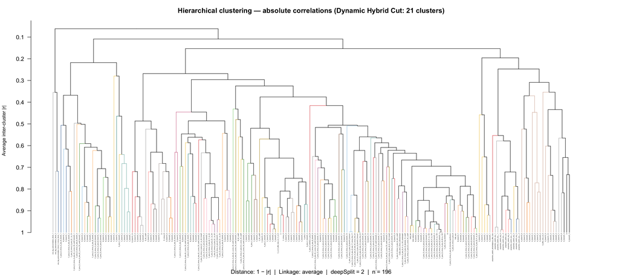

```r
clust_abs     <- setNames(dyn_abs, colnames(cor_whole))
unique_cl_abs <- sort(unique(clust_abs))
n_real_abs    <- sum(unique_cl_abs != 0)
pal_abs       <- c(if (0L %in% unique_cl_abs) "gray70",
                   rep_len(as.character(paletteer_d("ggthemes::Tableau_20")), n_real_abs))

dend_abs_col <- as.dendrogram(hc_abs) %>%
  color_branches(clusters = clust_abs, col = pal_abs) %>%
  set("labels_cex", 0.25) %>%
  set("leaves_pch", NA)

par(mar = c(5, 4.5, 3, 4))
plot(dend_abs_col,
     main = paste0("Hierarchical clustering — absolute correlations",
                   " (Dynamic Hybrid Cut: ", res_dyn_abs$summary$n_clusters, " clusters)"),
     xlab = "",
     sub  = paste0("Distance: 1 − |r|  |  Linkage: average  |  deepSplit = 2  |  n = ",
                   ncol(data_whole)),
     ylab = "",
     yaxt = "n")
axis(2, at = at_h_abs, labels = at_lbl_abs, las = 1)
mtext("Average inter-cluster |r|", side = 2, line = 3.5, cex = 0.85)
```